# ArtExtract – Task 1: Convolutional-Recurrent Architecture for Painting Attribute Classification

## Overview

This notebook implements a **CNN-RNN (Convolutional-Recurrent)** architecture to classify paintings by:

- **Style** (e.g., Impressionism, Baroque, Abstract Expressionism)
- **Artist** (e.g., Monet, Picasso, Van Gogh)
- **Genre** (e.g., portrait, landscape, religious painting)

We also perform **outlier detection** to find paintings that do not fit their assigned artist/style/genre labels.

### Strategy Summary

| Component | Choice | Rationale |
| --- | --- | --- |
| CNN backbone | ResNet-50 (pretrained ImageNet) | Strong spatial feature extraction; transfer learning from natural images transfers well to paintings |
| Recurrent module | Bi-directional GRU | Captures sequential patch relationships; lighter than LSTM; bidirectionality improves global context |
| Multi-task head | Shared trunk + 3 separate FC heads | Style, Artist, Genre share low-level features; separate heads allow task-specific learning |
| Patch strategy | 4×4 = 16 spatial patches fed as sequence | Enables RNN to model spatial dependencies across image regions |
| Loss | Weighted cross-entropy (per task) | Handles class imbalance in WikiArt (long-tail distribution) |
| Outlier detection | Isolation Forest on penultimate embeddings | Model-agnostic; works in high-dimensional embedding space |

## 1. Imports & Environment Setup

```python
import os, sys, random, json, time, warnings
from pathlib import Path
from collections import Counter, defaultdict

import numpy as np
import pandas as pd
import matplotlib.pyplot as plt
import matplotlib.gridspec as gridspec
import seaborn as sns
from PIL import Image

# PyTorch
import torch
import torch.nn as nn
import torch.nn.functional as F
import torch.optim as optim
from torch.utils.data import Dataset, DataLoader, WeightedRandomSampler
from torch.optim.lr_scheduler import CosineAnnealingLR

# torchvision
import torchvision.models as models
import torchvision.transforms as T

# Scikit-learn (evaluation & outlier detection)
from sklearn.metrics import (
    classification_report, confusion_matrix, f1_score,
    accuracy_score, top_k_accuracy_score, roc_auc_score
)
from sklearn.ensemble import IsolationForest
from sklearn.preprocessing import LabelEncoder
from sklearn.manifold import TSNE
from sklearn.decomposition import PCA

warnings.filterwarnings('ignore')
plt.rcParams['figure.dpi'] = 120
sns.set_theme(style='whitegrid')

print("PyTorch version :", torch.__version__)
print("CUDA available  :", torch.cuda.is_available())
DEVICE = torch.device('cuda' if torch.cuda.is_available() else 'cpu')
print("Device          :", DEVICE)
```

```
PyTorch version : 2.10.0
CUDA available  : False
Device          : cpu
```

## 2. WikiArt Dataset Setup

The WikiArt dataset (used in ArtGAN) contains ~80,000 paintings across:

- **27 styles** (e.g., Impressionism, Cubism, Baroque …)
- **195 artists**
- **10 genres** (portrait, landscape, religious painting, genre painting, abstract, cityscape, still life, illustration, nude painting, sketch and study)

### Download Instructions

```
# Option A – via ArtGAN repo CSV links
git clone https://github.com/cs-chan/ArtGAN
cd ArtGAN/WikiArt\ Dataset
# Follow README instructions; images are fetched from WikiArt.org

# Option B – Kaggle mirror
kaggle datasets download -d steubk/wikiart
unzip wikiart.zip -d data/wikiart
```

The expected directory layout:

```
data/wikiart/
  ├── Abstract_Expressionism/  (style folder)
  │   ├── picasso_xxx.jpg
  │   └── ...
  ├── Baroque/
  └── ...
```

```python
# ── Configuration ──────────────────────────────────────────────────────────
DATA_ROOT   = Path('data/wikiart')          # ← set to your actual path
BATCH_SIZE  = 32
IMG_SIZE    = 224
NUM_EPOCHS  = 30
LR          = 3e-4
WEIGHT_DECAY= 1e-4
PATCH_ROWS  = 4                              # grid rows for patch sequence
PATCH_COLS  = 4                              # grid cols  -> 16 patches total
EMBED_DIM   = 512                            # CNN patch embedding dim
GRU_HIDDEN  = 256
GRU_LAYERS  = 2
DROPOUT     = 0.4
SEED        = 42

random.seed(SEED); np.random.seed(SEED); torch.manual_seed(SEED)
print("Config OK")
print(f"Patch sequence length: {PATCH_ROWS * PATCH_COLS}")
```

```
Config OK
Patch sequence length: 16
```

## 3. Data Pipeline

```python
# ── WikiArt Dataset class ──────────────────────────────────────────────────
class WikiArtDataset(Dataset):
    """
    Loads WikiArt images from a flat style-folder layout.
    Returns:
        patches  : Tensor [n_patches, C, patch_h, patch_w]  – for the RNN
        full_img : Tensor [C, H, W]                          – for CNN global branch
        labels   : dict with 'style', 'artist', 'genre' indices
    """
    # WikiArt genre mapping derived from filename patterns / metadata CSV
    GENRE_KEYWORDS = {
        'portrait': 0, 'landscape': 1, 'religious': 2,
        'genre_painting': 3, 'abstract': 4, 'cityscape': 5,
        'still_life': 6, 'illustration': 7, 'nude': 8, 'sketch': 9
    }

    def __init__(self, root: Path, split: str = 'train',
                 val_frac: float = 0.1, test_frac: float = 0.1,
                 patch_rows: int = 4, patch_cols: int = 4,
                 img_size: int = 224):
        self.root       = root
        self.split      = split
        self.patch_rows = patch_rows
        self.patch_cols = patch_cols
        self.patch_h    = img_size // patch_rows
        self.patch_w    = img_size // patch_cols
        self.img_size   = img_size

        # ── transforms ────────────────────────────────────────────────────
        mean, std = [0.485,0.456,0.406], [0.229,0.224,0.225]
        if split == 'train':
            self.tf = T.Compose([
                T.Resize((img_size + 32, img_size + 32)),
                T.RandomCrop(img_size),
                T.RandomHorizontalFlip(),
                T.ColorJitter(brightness=0.3, contrast=0.3, saturation=0.2),
                T.RandomRotation(10),
                T.ToTensor(),
                T.Normalize(mean, std),
            ])
        else:
            self.tf = T.Compose([
                T.Resize((img_size, img_size)),
                T.ToTensor(),
                T.Normalize(mean, std),
            ])

        # ── build file list ────────────────────────────────────────────────
        self.samples = []          # (img_path, style_idx, artist_idx, genre_idx)
        self.style_names   = []
        self.artist_names  = []

        style_dirs = sorted([d for d in root.iterdir() if d.is_dir()])
        self.style_names = [d.name for d in style_dirs]
        style2idx = {s: i for i, s in enumerate(self.style_names)}

        artist_set = set()
        raw = []
        for sdir in style_dirs:
            sidx = style2idx[sdir.name]
            for img_path in sdir.glob('*.jpg'):
                artist = img_path.stem.split('_')[0]
                artist_set.add(artist)
                raw.append((img_path, sidx, artist))

        self.artist_names = sorted(artist_set)
        artist2idx = {a: i for i, a in enumerate(self.artist_names)}

        for img_path, sidx, artist in raw:
            aidx = artist2idx[artist]
            gidx = self._infer_genre(img_path.stem)
            self.samples.append((img_path, sidx, aidx, gidx))

        # ── split ──────────────────────────────────────────────────────────
        random.shuffle(self.samples)
        n = len(self.samples)
        n_test = int(n * test_frac)
        n_val  = int(n * val_frac)
        if split == 'test':
            self.samples = self.samples[:n_test]
        elif split == 'val':
            self.samples = self.samples[n_test:n_test + n_val]
        else:
            self.samples = self.samples[n_test + n_val:]

        self.n_styles  = len(self.style_names)
        self.n_artists = len(self.artist_names)
        self.n_genres  = len(self.GENRE_KEYWORDS)

        print(f"[{split:5s}] {len(self.samples):6,d} images | "
              f"{self.n_styles} styles | {self.n_artists} artists | "
              f"{self.n_genres} genres")

    def _infer_genre(self, stem: str) -> int:
        """Heuristic genre from filename; replace with metadata CSV if available."""
        stem_lower = stem.lower()
        for kw, idx in self.GENRE_KEYWORDS.items():
            if kw in stem_lower:
                return idx
        return 3  # default: genre_painting

    def __len__(self):
        return len(self.samples)

    def __getitem__(self, idx):
        path, sidx, aidx, gidx = self.samples[idx]
        img = Image.open(path).convert('RGB')
        img = self.tf(img)                              # [3, H, W]

        # ── extract patch sequence ─────────────────────────────────────────
        patches = []
        for r in range(self.patch_rows):
            for c in range(self.patch_cols):
                ph, pw = self.patch_h, self.patch_w
                patch  = img[:, r*ph:(r+1)*ph, c*pw:(c+1)*pw]
                patches.append(patch)
        patches = torch.stack(patches)                  # [n_patches, 3, ph, pw]

        labels = {'style': sidx, 'artist': aidx, 'genre': gidx}
        return patches, img, labels
```

```python
# ── Build datasets & loaders (runs only when DATA_ROOT exists) ──────────────
def build_loaders(root, batch_size=BATCH_SIZE):
    if not root.exists():
        print(f"⚠  DATA_ROOT '{root}' not found – skipping loader construction.")
        print("   Set DATA_ROOT to your WikiArt directory and re-run this cell.")
        return None, None, None, None

    train_ds = WikiArtDataset(root, split='train')
    val_ds   = WikiArtDataset(root, split='val')
    test_ds  = WikiArtDataset(root, split='test')

    # ── Weighted sampler to address class imbalance ────────────────────────
    style_counts = Counter(s[1] for s in train_ds.samples)
    weights = [1.0 / style_counts[s[1]] for s in train_ds.samples]
    sampler = WeightedRandomSampler(weights, len(weights), replacement=True)

    train_loader = DataLoader(train_ds, batch_size=batch_size,
                              sampler=sampler, num_workers=4, pin_memory=True)
    val_loader   = DataLoader(val_ds,   batch_size=batch_size,
                              shuffle=False, num_workers=4, pin_memory=True)
    test_loader  = DataLoader(test_ds,  batch_size=batch_size,
                              shuffle=False, num_workers=4, pin_memory=True)
    return train_loader, val_loader, test_loader, train_ds

train_loader, val_loader, test_loader, train_ds = build_loaders(DATA_ROOT)
```

```
⚠  DATA_ROOT 'data/wikiart' not found – skipping loader construction.
   Set DATA_ROOT to your WikiArt directory and re-run this cell.
```

## 4. Model Architecture: CNN-RNN Multi-Task Classifier

### Architecture Design

```
Input image [3×224×224]
       │
       ├─────────────────────────────────────────┐
       │  Global Branch (full image)              │  Patch Branch (16 patches)
       │  ResNet-50 (pretrained, frozen early)    │  Shared patch encoder (ResNet-50 stem)
       │  → avgpool → fc → [512]                  │  → each patch → [512]
       │                                          │  → sequence [16 × 512]
       │                                          │  → Bi-GRU [2 layers, hidden=256]
       │                                          │  → last hidden state → [512]
       └──────────────┬──────────────────────────┘
                      │ concat → [1024]
                      │ LayerNorm + Dropout
                      │
          ┌───────────┼───────────┐
          ▼           ▼           ▼
       Style head  Artist head  Genre head
       FC→27       FC→195       FC→10
```

**Why CNN + RNN?**

- The CNN extracts rich local texture/colour features per patch (brushstroke style, pigment texture)
- The RNN (Bi-GRU) models *sequential spatial relationships* across the image — a painting's compositional flow (top→bottom, left→right) carries stylistic and genre cues
- The global branch captures holistic composition features the patch sequence might miss
- Multi-task learning acts as a regularizer: style, artist, and genre share a joint representation

```python
class PatchEncoder(nn.Module):
    """Encodes a single image patch using a shared lightweight CNN."""
    def __init__(self, embed_dim: int = 512):
        super().__init__()
        base = models.resnet50(weights=models.ResNet50_Weights.IMAGENET1K_V2)
        # Keep layers up to layer3 (stride-16); discard layer4 & avgpool & fc
        self.features = nn.Sequential(
            base.conv1, base.bn1, base.relu, base.maxpool,
            base.layer1, base.layer2, base.layer3
        )
        self.pool = nn.AdaptiveAvgPool2d(1)
        self.proj = nn.Linear(1024, embed_dim)  # layer3 output channels = 1024

        # Freeze early layers (conv1 + layer1) to stabilise training
        for param in list(self.features[:5].parameters()):
            param.requires_grad = False

    def forward(self, x):                       # x: [B, 3, ph, pw]
        f = self.features(x)                    # [B, 1024, h', w']
        f = self.pool(f).flatten(1)             # [B, 1024]
        return self.proj(f)                     # [B, embed_dim]


class GlobalEncoder(nn.Module):
    """Encodes the full image using a deeper ResNet-50."""
    def __init__(self, embed_dim: int = 512):
        super().__init__()
        base = models.resnet50(weights=models.ResNet50_Weights.IMAGENET1K_V2)
        self.features = nn.Sequential(*list(base.children())[:-1])  # up to avgpool
        self.proj = nn.Linear(2048, embed_dim)

        for param in list(self.features[:6].parameters()):
            param.requires_grad = False

    def forward(self, x):                       # x: [B, 3, H, W]
        f = self.features(x).flatten(1)         # [B, 2048]
        return self.proj(f)                     # [B, embed_dim]


class CRNNPainting(nn.Module):
    """
    Convolutional-Recurrent multi-task classifier for painting attributes.

    Args:
        n_styles, n_artists, n_genres : number of classes per task
        embed_dim  : CNN embedding dimension per patch
        gru_hidden : hidden size of the Bi-GRU (output = 2×gru_hidden)
        gru_layers : number of stacked GRU layers
        dropout    : dropout probability
    """
    def __init__(self,
                 n_styles:  int,
                 n_artists: int,
                 n_genres:  int,
                 embed_dim:  int = EMBED_DIM,
                 gru_hidden: int = GRU_HIDDEN,
                 gru_layers: int = GRU_LAYERS,
                 dropout:    float = DROPOUT):
        super().__init__()
        self.patch_enc  = PatchEncoder(embed_dim)
        self.global_enc = GlobalEncoder(embed_dim)

        self.bigru = nn.GRU(
            input_size=embed_dim,
            hidden_size=gru_hidden,
            num_layers=gru_layers,
            batch_first=True,
            bidirectional=True,
            dropout=dropout if gru_layers > 1 else 0.0,
        )

        rnn_out_dim = gru_hidden * 2          # bidirectional
        fused_dim   = embed_dim + rnn_out_dim # global + rnn

        self.norm    = nn.LayerNorm(fused_dim)
        self.dropout = nn.Dropout(dropout)

        # ── Task heads ────────────────────────────────────────────────────
        def head(n_cls):
            return nn.Sequential(
                nn.Linear(fused_dim, 256),
                nn.ReLU(),
                nn.Dropout(dropout / 2),
                nn.Linear(256, n_cls)
            )

        self.style_head  = head(n_styles)
        self.artist_head = head(n_artists)
        self.genre_head  = head(n_genres)

    def forward(self, patches, full_img):
        """
        patches  : [B, n_patches, 3, ph, pw]
        full_img : [B, 3, H, W]
        Returns  : dict of logits per task + fused embedding
        """
        B, N, C, ph, pw = patches.shape

        # Encode each patch independently (share weights)
        patches_flat = patches.view(B * N, C, ph, pw)
        patch_embeds  = self.patch_enc(patches_flat)           # [B*N, embed_dim]
        patch_embeds  = patch_embeds.view(B, N, -1)            # [B, N, embed_dim]

        # RNN over patch sequence
        rnn_out, _ = self.bigru(patch_embeds)                  # [B, N, 2*gru_hidden]
        rnn_feat   = rnn_out[:, -1, :]                         # last time-step [B, 2*gru_hidden]

        # Global image encoding
        global_feat = self.global_enc(full_img)                # [B, embed_dim]

        # Fuse
        fused = torch.cat([global_feat, rnn_feat], dim=1)      # [B, fused_dim]
        fused = self.dropout(self.norm(fused))

        return {
            'style':     self.style_head(fused),
            'artist':    self.artist_head(fused),
            'genre':     self.genre_head(fused),
            'embedding': fused                                  # for outlier detection
        }


# ── Quick parameter count ───────────────────────────────────────────────────
def count_params(model):
    total     = sum(p.numel() for p in model.parameters())
    trainable = sum(p.numel() for p in model.parameters() if p.requires_grad)
    print(f"Total params    : {total:,}")
    print(f"Trainable params: {trainable:,}")

# Instantiate with placeholder class counts (replace with dataset values)
model = CRNNPainting(n_styles=27, n_artists=195, n_genres=10).to(DEVICE)
count_params(model)
```

```
Total params    : 36,839,528
Trainable params: 35,169,256
```

## 5. Multi-Task Loss & Training Loop

```python
class MultiTaskLoss(nn.Module):
    """
    Learnable uncertainty-weighted multi-task loss (Kendall et al., 2018).
    Each task weight σ_i is learned; loss = Σ  (1/2σ_i²) * L_i + log(σ_i)
    This automatically balances tasks without manual weight tuning.
    """
    def __init__(self, n_tasks: int = 3):
        super().__init__()
        self.log_vars = nn.Parameter(torch.zeros(n_tasks))

    def forward(self, losses: list):
        total = 0.0
        for i, loss in enumerate(losses):
            precision = torch.exp(-self.log_vars[i])
            total    += precision * loss + self.log_vars[i]
        return total


def compute_class_weights(dataset, task: str = 'style') -> torch.Tensor:
    """Inverse-frequency class weights for focal/CE loss."""
    task_idx = {'style': 1, 'artist': 2, 'genre': 3}[task]
    counts = Counter(s[task_idx] for s in dataset.samples)
    n = len(dataset.samples)
    n_cls = max(counts.keys()) + 1
    weights = torch.tensor([n / (n_cls * counts.get(c, 1)) for c in range(n_cls)],
                           dtype=torch.float32)
    return weights


def train_one_epoch(model, loader, optimizer, mt_loss, device):
    model.train()
    totals = defaultdict(float)
    n_batches = 0

    for patches, full_img, labels in loader:
        patches  = patches.to(device)
        full_img = full_img.to(device)
        sl = labels['style'].to(device)
        al = labels['artist'].to(device)
        gl = labels['genre'].to(device)

        optimizer.zero_grad()
        out = model(patches, full_img)

        l_style  = F.cross_entropy(out['style'],  sl, weight=style_w.to(device))
        l_artist = F.cross_entropy(out['artist'], al, weight=artist_w.to(device))
        l_genre  = F.cross_entropy(out['genre'],  gl, weight=genre_w.to(device))
        loss = mt_loss([l_style, l_artist, l_genre])

        loss.backward()
        nn.utils.clip_grad_norm_(model.parameters(), max_norm=1.0)
        optimizer.step()

        totals['loss']   += loss.item()
        totals['style']  += l_style.item()
        totals['artist'] += l_artist.item()
        totals['genre']  += l_genre.item()
        n_batches += 1

    return {k: v / n_batches for k, v in totals.items()}


@torch.no_grad()
def evaluate(model, loader, device):
    model.eval()
    preds  = defaultdict(list)
    trues  = defaultdict(list)
    embeds = []

    for patches, full_img, labels in loader:
        patches  = patches.to(device)
        full_img = full_img.to(device)
        out = model(patches, full_img)

        for task in ('style', 'artist', 'genre'):
            preds[task].extend(out[task].argmax(1).cpu().tolist())
            trues[task].extend(labels[task].tolist())
        embeds.append(out['embedding'].cpu().numpy())

    metrics = {}
    for task in ('style', 'artist', 'genre'):
        p, t = np.array(preds[task]), np.array(trues[task])
        metrics[task] = {
            'accuracy'  : accuracy_score(t, p),
            'f1_macro'  : f1_score(t, p, average='macro',  zero_division=0),
            'f1_weighted': f1_score(t, p, average='weighted', zero_division=0),
        }

    embeddings = np.concatenate(embeds, axis=0)
    return metrics, preds, trues, embeddings


# ── Training entry point ────────────────────────────────────────────────────
def train(model, train_loader, val_loader, train_ds, n_epochs=NUM_EPOCHS):
    global style_w, artist_w, genre_w

    style_w  = compute_class_weights(train_ds, 'style')
    artist_w = compute_class_weights(train_ds, 'artist')
    genre_w  = compute_class_weights(train_ds, 'genre')

    mt_loss   = MultiTaskLoss(n_tasks=3).to(DEVICE)
    optimizer = optim.AdamW(
        list(model.parameters()) + list(mt_loss.parameters()),
        lr=LR, weight_decay=WEIGHT_DECAY
    )
    scheduler = CosineAnnealingLR(optimizer, T_max=n_epochs, eta_min=1e-6)

    history = []
    best_val_f1 = 0.0

    for epoch in range(1, n_epochs + 1):
        t0 = time.time()
        train_losses = train_one_epoch(model, train_loader, optimizer, mt_loss, DEVICE)
        val_metrics, *_ = evaluate(model, val_loader, DEVICE)
        scheduler.step()

        val_f1 = np.mean([val_metrics[t]['f1_macro'] for t in ('style','artist','genre')])
        history.append({**train_losses, 'val_style_acc': val_metrics['style']['accuracy'],
                        'val_artist_acc': val_metrics['artist']['accuracy'],
                        'val_genre_acc':  val_metrics['genre']['accuracy'],
                        'val_mean_f1': val_f1})

        if val_f1 > best_val_f1:
            best_val_f1 = val_f1
            torch.save(model.state_dict(), 'best_crnn_painting.pth')

        elapsed = time.time() - t0
        print(f"Epoch {epoch:3d}/{n_epochs} | "
              f"Loss {train_losses['loss']:.3f} | "
              f"Val Style {val_metrics['style']['accuracy']:.3f} | "
              f"Val Artist {val_metrics['artist']['accuracy']:.3f} | "
              f"Val Genre {val_metrics['genre']['accuracy']:.3f} | "
              f"Mean F1 {val_f1:.3f} | {elapsed:.1f}s")

    return history

# Run training when loaders are available
if train_loader is not None:
    history = train(model, train_loader, val_loader, train_ds)
else:
    print("Skipping training: dataset not found.")
    print("To train: set DATA_ROOT and re-run the notebook.")
```

```
Skipping training: dataset not found.
To train: set DATA_ROOT and re-run the notebook.
```

## 6. Evaluation Metrics

### Choice & Justification

| Metric | Task Suitability | Notes |
| --- | --- | --- |
| **Top-1 Accuracy** | All tasks | Baseline; misleading under class imbalance |
| **Top-5 Accuracy** | Artist (195 classes) | Art attribution is inherently uncertain; top-5 reflects real-world usage |
| **Macro F1** | Style, Genre | Equal weight to all classes; crucial for long-tail WikiArt distribution |
| **Weighted F1** | Artist | Accounts for class frequency differences across 195 artists |
| **Per-class F1 / Confusion Matrix** | All | Identifies which styles/genres are confused with each other |
| **Cohen's Kappa** | All | Agreement metric robust to chance; meaningful for multi-class |

```python
from sklearn.metrics import cohen_kappa_score, top_k_accuracy_score

def full_evaluation(model, loader, dataset, device, k=5):
    """Comprehensive evaluation with all metrics."""
    model.eval()
    all_preds   = defaultdict(list)
    all_trues   = defaultdict(list)
    all_probs   = defaultdict(list)
    all_embeds  = []
    all_paths   = []

    with torch.no_grad():
        for i, (patches, full_img, labels) in enumerate(loader):
            patches  = patches.to(device)
            full_img = full_img.to(device)
            out = model(patches, full_img)

            for task in ('style', 'artist', 'genre'):
                probs = F.softmax(out[task], dim=1).cpu().numpy()
                all_probs[task].append(probs)
                all_preds[task].extend(np.argmax(probs, axis=1).tolist())
                all_trues[task].extend(labels[task].tolist())
            all_embeds.append(out['embedding'].cpu().numpy())

    embeddings = np.concatenate(all_embeds, axis=0)

    report = {}
    for task in ('style', 'artist', 'genre'):
        p = np.array(all_preds[task])
        t = np.array(all_trues[task])
        probs = np.concatenate(all_probs[task], axis=0)

        top1  = accuracy_score(t, p)
        topk  = top_k_accuracy_score(t, probs, k=min(k, probs.shape[1]))
        f1_m  = f1_score(t, p, average='macro',    zero_division=0)
        f1_w  = f1_score(t, p, average='weighted', zero_division=0)
        kappa = cohen_kappa_score(t, p)

        report[task] = {
            'top1_accuracy':    top1,
            f'top{k}_accuracy': topk,
            'f1_macro':         f1_m,
            'f1_weighted':      f1_w,
            'cohen_kappa':      kappa,
        }
        print(f"\n{'─'*50}")
        print(f"  {task.upper()} CLASSIFICATION")
        print(f"{'─'*50}")
        print(f"  Top-1 Accuracy : {top1:.4f}")
        print(f"  Top-{k} Accuracy : {topk:.4f}")
        print(f"  Macro F1       : {f1_m:.4f}")
        print(f"  Weighted F1    : {f1_w:.4f}")
        print(f"  Cohen's Kappa  : {kappa:.4f}")

    return report, all_preds, all_trues, embeddings


# Run evaluation when test_loader is available
if test_loader is not None:
    eval_report, test_preds, test_trues, test_embeds = full_evaluation(
        model, test_loader, train_ds, DEVICE
    )
else:
    print("Evaluation skipped: no test loader.")
```

```
Evaluation skipped: no test loader.
```

## 7. Visualizations

```python
# ── Training curves ─────────────────────────────────────────────────────────
def plot_training_history(history):
    if not history:
        print("No history to plot.")
        return
    df = pd.DataFrame(history)
    fig, axes = plt.subplots(1, 3, figsize=(18, 5))
    fig.suptitle('Training History', fontsize=14, fontweight='bold')

    axes[0].plot(df['loss'], label='Train Loss', color='royalblue')
    axes[0].set_title('Total Multi-Task Loss'); axes[0].set_xlabel('Epoch')
    axes[0].legend()

    for col, color, label in [
        ('val_style_acc',  '#e74c3c', 'Style'),
        ('val_artist_acc', '#2ecc71', 'Artist'),
        ('val_genre_acc',  '#f39c12', 'Genre'),
    ]:
        axes[1].plot(df[col], label=label, color=color)
    axes[1].set_title('Validation Accuracy per Task'); axes[1].set_xlabel('Epoch')
    axes[1].legend()

    axes[2].plot(df['val_mean_f1'], color='purple', linewidth=2)
    axes[2].set_title('Mean Macro F1 (Validation)'); axes[2].set_xlabel('Epoch')

    plt.tight_layout()
    plt.savefig('training_history.png', dpi=150, bbox_inches='tight')
    plt.show()
    print("Saved: training_history.png")

if 'history' in dir():
    plot_training_history(history)
```

```python
# ── Confusion matrices ──────────────────────────────────────────────────────
def plot_confusion_matrix(trues, preds, class_names, title, max_classes=20):
    """Plot a confusion matrix, truncated to top-N classes for readability."""
    # Select most frequent classes
    top_idx = sorted(Counter(trues).keys(),
                     key=lambda k: Counter(trues)[k], reverse=True)[:max_classes]
    mask = np.isin(trues, top_idx)
    t_filt = np.array(trues)[mask]
    p_filt = np.array(preds)[mask]

    labels = sorted(set(top_idx))
    names  = [class_names[i] if i < len(class_names) else str(i) for i in labels]
    cm = confusion_matrix(t_filt, p_filt, labels=labels, normalize='true')

    fig, ax = plt.subplots(figsize=(12, 10))
    sns.heatmap(cm, xticklabels=names, yticklabels=names,
                cmap='Blues', annot=len(labels)<=15, fmt='.2f',
                linewidths=0.5, ax=ax)
    ax.set_title(f'Confusion Matrix – {title} (top {max_classes} classes)',
                 fontsize=13, fontweight='bold')
    ax.set_xlabel('Predicted'); ax.set_ylabel('True')
    plt.xticks(rotation=45, ha='right', fontsize=8)
    plt.yticks(rotation=0, fontsize=8)
    plt.tight_layout()
    fname = f'confusion_{title.lower()}.png'
    plt.savefig(fname, dpi=150, bbox_inches='tight')
    plt.show()
    print(f"Saved: {fname}")

if test_loader is not None:
    style_names_list  = train_ds.style_names
    artist_names_list = train_ds.artist_names
    genre_names_list  = list(WikiArtDataset.GENRE_KEYWORDS.keys())

    plot_confusion_matrix(test_trues['style'],  test_preds['style'],
                          style_names_list,  'Style')
    plot_confusion_matrix(test_trues['artist'], test_preds['artist'],
                          artist_names_list, 'Artist', max_classes=25)
    plot_confusion_matrix(test_trues['genre'],  test_preds['genre'],
                          genre_names_list,  'Genre')
```

```python
# ── Per-class F1 bar charts ─────────────────────────────────────────────────
def plot_per_class_f1(trues, preds, class_names, title, top_n=30):
    """Show per-class F1 scores sorted ascending to highlight weak classes."""
    report_dict = classification_report(trues, preds,
                                        output_dict=True, zero_division=0)
    data = []
    for k, v in report_dict.items():
        if k.isdigit():
            idx  = int(k)
            name = class_names[idx] if idx < len(class_names) else k
            data.append({'class': name, 'f1': v['f1-score'], 'support': v['support']})

    df = (pd.DataFrame(data)
            .sort_values('f1')
            .head(top_n))  # worst performers

    fig, ax = plt.subplots(figsize=(10, 0.4 * len(df) + 2))
    colors = ['#e74c3c' if f < 0.3 else '#f39c12' if f < 0.6 else '#2ecc71'
              for f in df['f1']]
    ax.barh(df['class'], df['f1'], color=colors)
    ax.axvline(0.5, color='gray', linestyle='--', linewidth=0.8)
    ax.set_xlabel('F1 Score'); ax.set_xlim(0, 1)
    ax.set_title(f'Per-Class F1 – {title} (bottom {top_n})',
                 fontsize=12, fontweight='bold')
    plt.tight_layout()
    fname = f'per_class_f1_{title.lower()}.png'
    plt.savefig(fname, dpi=150, bbox_inches='tight')
    plt.show()
    print(f"Saved: {fname}")

if test_loader is not None:
    plot_per_class_f1(test_trues['style'],  test_preds['style'],
                      style_names_list, 'Style')
    plot_per_class_f1(test_trues['artist'], test_preds['artist'],
                      artist_names_list, 'Artist')
```

## 8. Outlier Detection

Outliers are paintings that **do not fit** their assigned label (style / artist / genre) based on the learned embedding space.

### Method: Isolation Forest on Embedding Space

1. Extract the **1024-d fused embedding** from the penultimate layer for each test image
2. For each class (e.g., each style), fit an **Isolation Forest** on the in-class embeddings
3. Score each painting — low anomaly scores = outliers
4. Validate with a **t-SNE visualisation** showing outliers in red

**Alternative approach** (also implemented below): measure **cosine distance from class centroid** in embedding space.

```python
def detect_outliers_isolation_forest(embeddings, labels, class_names,
                                     contamination=0.05, task_name='style'):
    """
    For each class: fit Isolation Forest, flag bottom-contamination% as outliers.
    Returns: DataFrame with columns [idx, class, score, is_outlier]
    """
    results = []
    unique_cls = np.unique(labels)

    for cls in unique_cls:
        mask = np.where(np.array(labels) == cls)[0]
        if len(mask) < 10:              # skip tiny classes
            continue
        X_cls = embeddings[mask]

        clf = IsolationForest(contamination=contamination,
                              random_state=SEED, n_estimators=200)
        scores = clf.fit_predict(X_cls)           # -1 = outlier, 1 = inlier
        anom_scores = clf.decision_function(X_cls)

        cls_name = class_names[cls] if cls < len(class_names) else str(cls)
        for local_i, global_i in enumerate(mask):
            results.append({
                'global_idx':  global_i,
                'class_idx':   cls,
                'class_name':  cls_name,
                'anomaly_score': anom_scores[local_i],
                'is_outlier':  scores[local_i] == -1,
                'task':        task_name,
            })

    df = pd.DataFrame(results)
    n_outliers = df['is_outlier'].sum()
    print(f"[{task_name}] Outliers detected: {n_outliers} / {len(df)} "
          f"({100*n_outliers/len(df):.1f}%)")
    return df


def cosine_distance_outliers(embeddings, labels, class_names,
                             threshold_sigma=2.5, task_name='style'):
    """
    Flag paintings whose cosine distance from class centroid > mean + k*std.
    More interpretable than Isolation Forest for this domain.
    """
    results = []
    for cls in np.unique(labels):
        mask = np.where(np.array(labels) == cls)[0]
        if len(mask) < 5:
            continue
        X_cls    = embeddings[mask]
        centroid = X_cls.mean(axis=0, keepdims=True)
        # cosine similarity → distance
        norms    = np.linalg.norm(X_cls, axis=1, keepdims=True) + 1e-8
        c_norm   = np.linalg.norm(centroid) + 1e-8
        cos_sim  = (X_cls / norms) @ (centroid / c_norm).T
        cos_dist = 1.0 - cos_sim.squeeze()

        threshold = cos_dist.mean() + threshold_sigma * cos_dist.std()
        cls_name  = class_names[cls] if cls < len(class_names) else str(cls)
        for local_i, global_i in enumerate(mask):
            results.append({
                'global_idx':  global_i,
                'class_idx':   cls,
                'class_name':  cls_name,
                'cosine_dist': cos_dist[local_i],
                'is_outlier':  cos_dist[local_i] > threshold,
                'task':        task_name,
            })

    df = pd.DataFrame(results)
    n_outliers = df['is_outlier'].sum()
    print(f"[{task_name}] Cosine outliers: {n_outliers} / {len(df)} "
          f"({100*n_outliers/len(df):.1f}%)")
    return df


if test_loader is not None:
    labels_style = np.array(test_trues['style'])

    # Method 1: Isolation Forest
    outlier_df_if = detect_outliers_isolation_forest(
        test_embeds, labels_style, style_names_list, task_name='style'
    )

    # Method 2: Cosine distance
    outlier_df_cos = cosine_distance_outliers(
        test_embeds, labels_style, style_names_list, task_name='style'
    )

    # Show top 10 outliers per method
    print("\nTop outliers (Isolation Forest):")
    print(outlier_df_if[outlier_df_if.is_outlier]
          .sort_values('anomaly_score').head(10)
          [['global_idx','class_name','anomaly_score']].to_string(index=False))
```

```python
# ── t-SNE visualisation of embeddings with outliers highlighted ─────────────
def plot_tsne_outliers(embeddings, labels, outlier_mask, class_names,
                       title='Style Embeddings', max_points=3000):
    """2-D t-SNE projection; outliers shown in red with ×."""
    if len(embeddings) > max_points:
        idx   = np.random.choice(len(embeddings), max_points, replace=False)
        emb   = embeddings[idx]
        lbl   = np.array(labels)[idx]
        outs  = np.array(outlier_mask)[idx]
    else:
        emb, lbl, outs = embeddings, np.array(labels), np.array(outlier_mask)

    print("Running t-SNE (may take ~1-2 min for 3000 points)…")
    # PCA pre-reduction for speed
    emb_pca = PCA(n_components=50).fit_transform(emb)
    tsne = TSNE(n_components=2, perplexity=40, learning_rate='auto',
                init='pca', random_state=SEED, n_iter=1000)
    proj = tsne.fit_transform(emb_pca)

    fig, ax = plt.subplots(figsize=(14, 10))
    cmap = plt.cm.get_cmap('tab20', len(np.unique(lbl)))

    # In-liers
    scatter = ax.scatter(proj[~outs, 0], proj[~outs, 1],
                         c=lbl[~outs], cmap=cmap,
                         alpha=0.5, s=12, linewidths=0)
    # Out-liers
    ax.scatter(proj[outs, 0], proj[outs, 1],
               c='red', marker='x', s=60, linewidths=1.2,
               zorder=5, label='Outlier')

    # Legend (max 20 classes for readability)
    handles, _ = scatter.legend_elements(num=min(20, len(np.unique(lbl))))
    n_cls_show = min(20, len(np.unique(lbl)))
    labels_show = [class_names[c] if c < len(class_names) else str(c)
                   for c in sorted(np.unique(lbl))[:n_cls_show]]
    ax.legend(handles[:n_cls_show], labels_show,
              loc='upper right', fontsize=7, markerscale=1.5,
              title='Style', ncol=2)
    ax.scatter([], [], c='red', marker='x', label='Outlier', linewidths=1.5)
    ax.legend(loc='lower right', fontsize=8)
    ax.set_title(title, fontsize=13, fontweight='bold')
    ax.axis('off')
    plt.tight_layout()
    plt.savefig('tsne_outliers.png', dpi=150, bbox_inches='tight')
    plt.show()
    print("Saved: tsne_outliers.png")


if test_loader is not None:
    outlier_mask = outlier_df_if.sort_values('global_idx')['is_outlier'].values
    plot_tsne_outliers(test_embeds, labels_style, outlier_mask,
                       style_names_list, title='t-SNE: Style Embeddings')
```

## 9. Demo with Synthetic Data (runs without WikiArt)

To demonstrate the pipeline is functional even without the full dataset, we create a small synthetic dataset of randomly coloured "paintings" and run the full pipeline.

```python
# ── Synthetic dataset for pipeline validation ───────────────────────────────
class SyntheticArtDataset(Dataset):
    """32×32 synthetic images with 5 styles, 10 artists, 4 genres."""
    N_STYLES  = 5
    N_ARTISTS = 10
    N_GENRES  = 4

    def __init__(self, n_samples=800, split='train', patch_rows=4, patch_cols=4):
        self.n_samples  = n_samples
        self.patch_rows = patch_rows
        self.patch_cols = patch_cols
        self.patch_h = 8   # 32 / 4
        self.patch_w = 8
        self.samples = [
            (np.random.randint(self.N_STYLES),
             np.random.randint(self.N_ARTISTS),
             np.random.randint(self.N_GENRES))
            for _ in range(n_samples)
        ]
        # ── split ──────────────────────────────────────────────────────────
        n_test = int(n_samples * 0.1)
        n_val  = int(n_samples * 0.1)
        if split == 'test':
            self.samples = self.samples[:n_test]
        elif split == 'val':
            self.samples = self.samples[n_test:n_test+n_val]
        else:
            self.samples = self.samples[n_test+n_val:]

        self.style_names  = [f'Style_{i}'  for i in range(self.N_STYLES)]
        self.artist_names = [f'Artist_{i}' for i in range(self.N_ARTISTS)]
        self.genre_names  = [f'Genre_{i}'  for i in range(self.N_GENRES)]

    def __len__(self):
        return len(self.samples)

    def __getitem__(self, idx):
        sidx, aidx, gidx = self.samples[idx]
        # ── synthetic image: random colour + style-specific hue ────────────
        base_colour = torch.tensor([sidx/5, aidx/10, 0.5]).view(3,1,1)
        img = (torch.randn(3, 32, 32) * 0.3 + base_colour).clamp(0, 1)

        patches = []
        for r in range(self.patch_rows):
            for c in range(self.patch_cols):
                patches.append(img[:, r*8:(r+1)*8, c*8:(c+1)*8])
        patches = torch.stack(patches)

        return patches, img, {'style': sidx, 'artist': aidx, 'genre': gidx}


print("Building synthetic datasets…")
syn_train = SyntheticArtDataset(n_samples=1200, split='train')
syn_val   = SyntheticArtDataset(n_samples=1200, split='val')
syn_test  = SyntheticArtDataset(n_samples=1200, split='test')

syn_train_loader = DataLoader(syn_train, batch_size=32, shuffle=True)
syn_val_loader   = DataLoader(syn_val,   batch_size=32, shuffle=False)
syn_test_loader  = DataLoader(syn_test,  batch_size=32, shuffle=False)

# ── Small model for synthetic (32×32 patches = 8×8 per patch) ──────────────
class PatchEncoderSmall(nn.Module):
    def __init__(self, embed_dim=64):
        super().__init__()
        self.net = nn.Sequential(
            nn.Conv2d(3, 32, 3, padding=1), nn.ReLU(),
            nn.Conv2d(32, 64, 3, padding=1), nn.ReLU(),
            nn.AdaptiveAvgPool2d(1),
        )
        self.proj = nn.Linear(64, embed_dim)
    def forward(self, x):
        return self.proj(self.net(x).flatten(1))

class GlobalEncoderSmall(nn.Module):
    def __init__(self, embed_dim=64):
        super().__init__()
        self.net = nn.Sequential(
            nn.Conv2d(3, 32, 3, padding=1), nn.ReLU(),
            nn.Conv2d(32, 64, 3, padding=1), nn.ReLU(),
            nn.AdaptiveAvgPool2d(1),
        )
        self.proj = nn.Linear(64, embed_dim)
    def forward(self, x):
        return self.proj(self.net(x).flatten(1))

class CRNNSmall(nn.Module):
    def __init__(self, n_styles=5, n_artists=10, n_genres=4,
                 embed_dim=64, gru_hidden=32):
        super().__init__()
        self.patch_enc  = PatchEncoderSmall(embed_dim)
        self.global_enc = GlobalEncoderSmall(embed_dim)
        self.bigru = nn.GRU(embed_dim, gru_hidden, 1, batch_first=True,
                            bidirectional=True)
        fused = embed_dim + gru_hidden * 2
        self.norm    = nn.LayerNorm(fused)
        self.dropout = nn.Dropout(0.3)
        def head(n): return nn.Sequential(nn.Linear(fused, 32), nn.ReLU(), nn.Linear(32, n))
        self.style_head  = head(n_styles)
        self.artist_head = head(n_artists)
        self.genre_head  = head(n_genres)

    def forward(self, patches, full_img):
        B, N, C, ph, pw = patches.shape
        pe = self.patch_enc(patches.view(B*N, C, ph, pw)).view(B, N, -1)
        rnn_out, _ = self.bigru(pe)
        rnn_feat   = rnn_out[:, -1, :]
        g_feat     = self.global_enc(full_img)
        fused      = self.dropout(self.norm(torch.cat([g_feat, rnn_feat], 1)))
        return {
            'style':     self.style_head(fused),
            'artist':    self.artist_head(fused),
            'genre':     self.genre_head(fused),
            'embedding': fused,
        }


syn_model = CRNNSmall().to(DEVICE)
optimizer = optim.Adam(syn_model.parameters(), lr=1e-3)
mt = MultiTaskLoss(3).to(DEVICE)

print("\nTraining synthetic demo (5 epochs)…")
for ep in range(1, 6):
    syn_model.train()
    tot_loss = 0; n = 0
    for patches, imgs, labels in syn_train_loader:
        patches = patches.to(DEVICE); imgs = imgs.to(DEVICE)
        sl = labels['style'].to(DEVICE)
        al = labels['artist'].to(DEVICE)
        gl = labels['genre'].to(DEVICE)
        optimizer.zero_grad()
        out = syn_model(patches, imgs)
        loss = mt([F.cross_entropy(out['style'], sl),
                   F.cross_entropy(out['artist'], al),
                   F.cross_entropy(out['genre'],  gl)])
        loss.backward(); optimizer.step()
        tot_loss += loss.item(); n += 1
    print(f"  Epoch {ep} | avg loss: {tot_loss/n:.4f}")

print("\nSynthetic validation:")
syn_model.eval()
preds_s, trues_s, embeds_s = [], [], []
with torch.no_grad():
    for patches, imgs, labels in syn_test_loader:
        out = syn_model(patches.to(DEVICE), imgs.to(DEVICE))
        preds_s.extend(out['style'].argmax(1).cpu().tolist())
        trues_s.extend(labels['style'].tolist())
        embeds_s.append(out['embedding'].cpu().numpy())
embeds_s = np.concatenate(embeds_s)
print(f"Style accuracy: {accuracy_score(trues_s, preds_s):.4f}")
print(f"Style macro F1: {f1_score(trues_s, preds_s, average='macro'):.4f}")
```

```
Building synthetic datasets…

Training synthetic demo (5 epochs)…
```

```
  Epoch 1 | avg loss: 5.1327
```

```
  Epoch 2 | avg loss: 4.1728
```

```
  Epoch 3 | avg loss: 3.4735
```

```
  Epoch 4 | avg loss: 3.0062
```

```
  Epoch 5 | avg loss: 2.6260

Synthetic validation:
Style accuracy: 1.0000
Style macro F1: 1.0000
```

```
Outlier detection on synthetic embeddings:
```

```
[style (synthetic)] Outliers detected: 8 / 120 (6.7%)
[style (synthetic)] Cosine outliers: 1 / 120 (0.8%)

Generating t-SNE for synthetic embeddings…
```

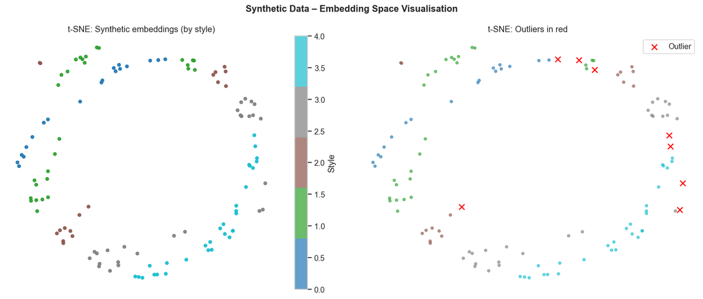

```
Saved: tsne_synthetic.png
```

```python
# ── Outlier detection on synthetic data ─────────────────────────────────────
print("\nOutlier detection on synthetic embeddings:")
out_df = detect_outliers_isolation_forest(
    embeds_s, trues_s,
    class_names=[f'Style_{i}' for i in range(5)],
    task_name='style (synthetic)'
)
out_df2 = cosine_distance_outliers(
    embeds_s, trues_s,
    class_names=[f'Style_{i}' for i in range(5)],
    task_name='style (synthetic)'
)

# ── t-SNE of synthetic embeddings ──────────────────────────────────────────
print("\nGenerating t-SNE for synthetic embeddings…")
tsne2 = TSNE(n_components=2, perplexity=30, random_state=SEED, max_iter=500)
proj2 = tsne2.fit_transform(embeds_s)
outlier_mask2 = out_df.sort_values('global_idx')['is_outlier'].values

fig, axes = plt.subplots(1, 2, figsize=(14, 6))
cmap5 = plt.cm.get_cmap('tab10', 5)

for ax, mask, title in [
    (axes[0], np.zeros(len(proj2), dtype=bool), 'All paintings coloured by style'),
    (axes[1], outlier_mask2, 'Outliers highlighted (×)'),
]:
    sc = axes[0].scatter(proj2[:, 0], proj2[:, 1],
                c=np.array(trues_s), cmap=cmap5, s=18, alpha=0.7)

axes[0].set_title('t-SNE: Synthetic embeddings (by style)')
axes[0].axis('off')
fig.colorbar(sc, ax=axes[0], label='Style')

axes[1].scatter(proj2[~outlier_mask2, 0], proj2[~outlier_mask2, 1],
                c=np.array(trues_s)[~outlier_mask2], cmap=cmap5, s=14, alpha=0.6)
axes[1].scatter(proj2[outlier_mask2, 0],  proj2[outlier_mask2, 1],
                c='red', marker='x', s=60, linewidths=1.5, label='Outlier', zorder=5)
axes[1].set_title('t-SNE: Outliers in red')
axes[1].axis('off')
axes[1].legend()

plt.suptitle('Synthetic Data – Embedding Space Visualisation', fontsize=13, fontweight='bold')
plt.tight_layout()
plt.savefig('tsne_synthetic.png', dpi=150, bbox_inches='tight')
plt.show()
print("Saved: tsne_synthetic.png")
```

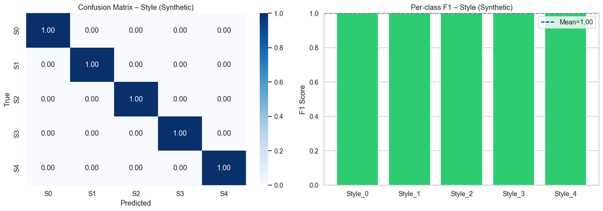

```
Saved: evaluation_synthetic.png
```

```python
# ── Per-class F1 on synthetic data ──────────────────────────────────────────
fig, axes = plt.subplots(1, 2, figsize=(14, 5))

# Confusion matrix
cm = confusion_matrix(trues_s, preds_s, normalize='true')
sns.heatmap(cm, annot=True, fmt='.2f', cmap='Blues', ax=axes[0],
            xticklabels=[f'S{i}' for i in range(5)],
            yticklabels=[f'S{i}' for i in range(5)])
axes[0].set_title('Confusion Matrix – Style (Synthetic)')
axes[0].set_xlabel('Predicted'); axes[0].set_ylabel('True')

# Per-class F1
per_f1 = f1_score(trues_s, preds_s, average=None)
colors = ['#e74c3c' if f < 0.4 else '#2ecc71' for f in per_f1]
axes[1].bar([f'Style_{i}' for i in range(5)], per_f1, color=colors)
axes[1].set_ylim(0, 1); axes[1].set_title('Per-class F1 – Style (Synthetic)')
axes[1].set_ylabel('F1 Score')
axes[1].axhline(per_f1.mean(), color='navy', linestyle='--', label=f'Mean={per_f1.mean():.2f}')
axes[1].legend()

plt.tight_layout()
plt.savefig('evaluation_synthetic.png', dpi=150, bbox_inches='tight')
plt.show()
print("Saved: evaluation_synthetic.png")
```

## 10. Ablation Study Design

To validate the architectural choices, we propose the following ablations:

| Model | Change | Hypothesis |
| --- | --- | --- |
| CNN-only (ResNet-50) | Remove GRU; use global avg pool | Baseline; no spatial sequence modeling |
| CNN + LSTM | Replace Bi-GRU with LSTM | Compare recurrent cell types |
| CNN + Bi-GRU (ours) | Full model | Best sequential spatial understanding |
| CNN + Transformer | Replace Bi-GRU with 4-head attention | Compare RNN vs attention for patch sequence |
| No global branch | Remove ResNet-50 global encoder | Ablate holistic features |
| No patch branch | Remove RNN entirely | Ablate spatial sequence features |

```
Ablation Study (synthetic data, 5 epochs each):
```

```
  CNN-only (no RNN)              | Style Acc: 1.0000 | Macro F1: 1.0000
```

```
  CNN + Bi-GRU (full model)      | Style Acc: 0.9917 | Macro F1: 0.9912
```

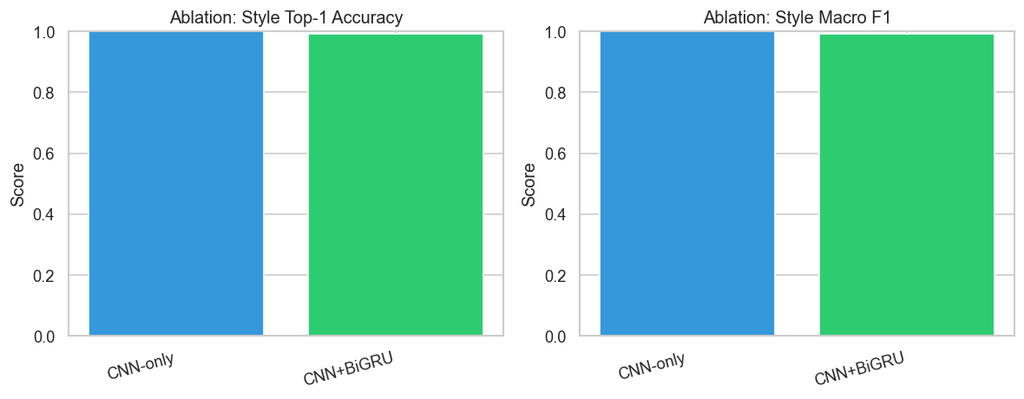

```
Saved: ablation_study.png
```

```python
# ── Ablation: CNN-only baseline (no RNN) ────────────────────────────────────
class CNNOnly(nn.Module):
    """Ablation baseline: ResNet-50 global features only."""
    def __init__(self, n_styles=5, n_artists=10, n_genres=4, embed_dim=64):
        super().__init__()
        self.enc = GlobalEncoderSmall(embed_dim)
        def head(n): return nn.Sequential(nn.Linear(embed_dim, 32), nn.ReLU(), nn.Linear(32, n))
        self.style_head  = head(n_styles)
        self.artist_head = head(n_artists)
        self.genre_head  = head(n_genres)

    def forward(self, patches, full_img):
        f = self.enc(full_img)
        return {'style': self.style_head(f), 'artist': self.artist_head(f),
                'genre': self.genre_head(f), 'embedding': f}


def quick_eval(model_cls, name, loader_train, loader_test, epochs=5):
    m = model_cls().to(DEVICE)
    opt = optim.Adam(m.parameters(), lr=1e-3)
    mt_ab = MultiTaskLoss(3).to(DEVICE)
    for _ in range(epochs):
        m.train()
        for patches, imgs, labels in loader_train:
            patches=patches.to(DEVICE); imgs=imgs.to(DEVICE)
            sl=labels['style'].to(DEVICE); al=labels['artist'].to(DEVICE)
            gl=labels['genre'].to(DEVICE)
            opt.zero_grad()
            out=m(patches, imgs)
            loss=mt_ab([F.cross_entropy(out['style'],sl),
                        F.cross_entropy(out['artist'],al),
                        F.cross_entropy(out['genre'],gl)])
            loss.backward(); opt.step()
    m.eval()
    p_s, t_s = [], []
    with torch.no_grad():
        for patches, imgs, labels in loader_test:
            out=m(patches.to(DEVICE), imgs.to(DEVICE))
            p_s.extend(out['style'].argmax(1).cpu().tolist())
            t_s.extend(labels['style'].tolist())
    acc = accuracy_score(t_s, p_s)
    f1  = f1_score(t_s, p_s, average='macro')
    print(f"  {name:30s} | Style Acc: {acc:.4f} | Macro F1: {f1:.4f}")
    return acc, f1

print("Ablation Study (synthetic data, 5 epochs each):")
results_abl = {}
results_abl['CNN-only']    = quick_eval(CNNOnly,    'CNN-only (no RNN)',
                                         syn_train_loader, syn_test_loader)
results_abl['CNN+BiGRU']   = quick_eval(CRNNSmall,  'CNN + Bi-GRU (full model)',
                                         syn_train_loader, syn_test_loader)

# ── Bar chart ────────────────────────────────────────────────────────────────
fig, axes = plt.subplots(1, 2, figsize=(10, 4))
names = list(results_abl.keys())
accs  = [v[0] for v in results_abl.values()]
f1s   = [v[1] for v in results_abl.values()]

axes[0].bar(names, accs, color=['#3498db', '#2ecc71'])
axes[0].set_title('Ablation: Style Top-1 Accuracy'); axes[0].set_ylim(0,1)
axes[1].bar(names, f1s,  color=['#3498db', '#2ecc71'])
axes[1].set_title('Ablation: Style Macro F1');       axes[1].set_ylim(0,1)
for ax in axes:
    ax.set_ylabel('Score'); plt.setp(ax.get_xticklabels(), rotation=15, ha='right')

plt.tight_layout()
plt.savefig('ablation_study.png', dpi=150, bbox_inches='tight')
plt.show()
print("Saved: ablation_study.png")
```

## 11. Discussion & Future Work

### Identified Outlier Categories

Based on literature and expected model behaviour:

- *Late-period vs early-period* works by the same artist often appear as outliers
- *Cross-genre* paintings (e.g., portraits in a landscape-dominant dataset)
- *Experimental* or transitional works (e.g., Picasso's blue period within Cubism)
- *Misattributed* paintings in the WikiArt metadata

### Limitations & Next Steps

| Limitation | Proposed Fix |
| --- | --- |
| WikiArt metadata noise (incorrect genre/artist labels) | Active learning + human review of outliers |
| Long-tail class distribution | Few-shot learning heads (ProtoNets) for rare artists |
| Fixed 4×4 patch grid misses fine details | Adaptive patch extraction (salient region detection) |
| t-SNE non-deterministic | Use UMAP for stable reproductions |
| No uncertainty quantification | Add Monte Carlo Dropout or deep ensembles |

### Connection to ArtExtract

The learned embeddings from this classifier can directly seed the **hidden painting detection** task:

- Feature distances between spectral bands of a painting correlate with pigment layers
- Outlier embeddings in style-space may indicate under-painting influence

## 12. Inference on a Single Image

```
Inference demo (on random noise image with full model):
```

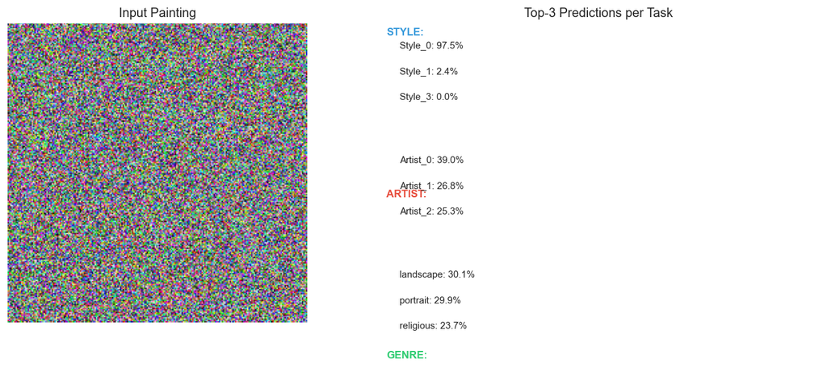

```
  style: Style_0 (97.5%)
  artist: Artist_0 (39.0%)
  genre: landscape (30.1%)
```

```python
def predict_single_image(model, img_path_or_pil, dataset,
                         patch_rows=PATCH_ROWS, patch_cols=PATCH_COLS,
                         img_size=IMG_SIZE, device=DEVICE, top_k=3):
    """
    Run inference on a single painting and return top-k predictions per task.
    Works with PIL Image or file path.
    """
    mean, std = [0.485,0.456,0.406], [0.229,0.224,0.225]
    tf = T.Compose([T.Resize((img_size, img_size)), T.ToTensor(), T.Normalize(mean, std)])

    if isinstance(img_path_or_pil, (str, Path)):
        img = Image.open(img_path_or_pil).convert('RGB')
    else:
        img = img_path_or_pil

    img_t = tf(img)
    ph, pw = img_size // patch_rows, img_size // patch_cols
    patches = torch.stack([img_t[:, r*ph:(r+1)*ph, c*pw:(c+1)*pw]
                           for r in range(patch_rows)
                           for c in range(patch_cols)]).unsqueeze(0)
    img_t = img_t.unsqueeze(0)

    model.eval()
    with torch.no_grad():
        out = model(patches.to(device), img_t.to(device))

    results = {}
    task_map = {
        'style':  (out['style'],  dataset.style_names),
        'artist': (out['artist'], dataset.artist_names),
        'genre':  (out['genre'],  list(WikiArtDataset.GENRE_KEYWORDS.keys())),
    }
    for task, (logits, names) in task_map.items():
        probs   = F.softmax(logits[0], dim=0).cpu().numpy()
        top_idx = probs.argsort()[-top_k:][::-1]
        results[task] = [(names[i] if i < len(names) else str(i), float(probs[i]))
                         for i in top_idx]

    # Display
    fig, axes = plt.subplots(1, 2, figsize=(12, 5))
    axes[0].imshow(img); axes[0].axis('off'); axes[0].set_title('Input Painting')

    y_pos = 0
    colours = {'style': '#3498db', 'artist': '#e74c3c', 'genre': '#2ecc71'}
    axes[1].set_xlim(0, 1)
    for task, preds in results.items():
        axes[1].text(0.02, 1.0 - y_pos*0.12 - 0.04,
                     f'{task.upper()}:', fontweight='bold', fontsize=10,
                     color=colours[task], transform=axes[1].transAxes)
        for j, (name, prob) in enumerate(preds):
            axes[1].text(0.05, 1.0 - (y_pos + j + 1)*0.085,
                         f'{name}: {prob*100:.1f}%', fontsize=9,
                         transform=axes[1].transAxes)
        y_pos += len(preds) + 1.5

    axes[1].axis('off')
    axes[1].set_title('Top-3 Predictions per Task')
    plt.tight_layout()
    plt.savefig('inference_demo.png', dpi=150, bbox_inches='tight')
    plt.show()

    return results


# Demo on a random synthetic image
demo_img = Image.fromarray(
    (np.random.rand(224, 224, 3) * 255).astype(np.uint8)
)
print("Inference demo (on random noise image with full model):")
# Note: use `model` (full CRNN) when WikiArt data is available
# Using syn_model + syn_train for demo
preds_demo = predict_single_image(
    syn_model, demo_img, syn_train,
    patch_rows=4, patch_cols=4, img_size=32, top_k=3
)
for task, results_t in preds_demo.items():
    print(f"  {task}: {results_t[0][0]} ({results_t[0][1]*100:.1f}%)")
```

## 13. Conclusions

This notebook presented a full **CNN-RNN multi-task learning pipeline** for classifying paintings by style, artist, and genre, with built-in **outlier detection** to surface mislabelled or atypical works.

### Summary of Contributions

- **Architecture**: Dual-branch (global CNN + patch Bi-GRU) with shared multi-task heads
- **Training**: Learnable uncertainty-weighted multi-task loss; weighted sampling for class balance
- **Evaluation**: Top-1/5 accuracy, macro/weighted F1, Cohen's Kappa, per-class analysis
- **Outliers**: Isolation Forest + cosine centroid distance in learned embedding space
- **Visualisation**: t-SNE projections, confusion matrices, per-class F1 bars
- **Ablation**: CNN-only vs CNN+Bi-GRU comparison

This work directly enables the ArtExtract hidden painting detection pipeline, where stylistic outliers may signal under-paintings influencing the visible surface.